# Statistical Inference Course Project

Aiyu Li

01/16/2021

# 1 Synopsis

This is a project for Statistical Inference class. There are two parts in this project.

- Part 1: simulation Exercise: investigate the distribution of averages of 40 exponentials and a thousand simulations in R and compare it with the Central Limit Theorem. The exponential distribution can be simulated in R with rexp(n, lambda) where lambda is the rate parameter. The mean of exponential distribution is 1/lambda and the standard deviation is also 1/lambda. Set lambda = 0.2 for all of the simulations.
- Part 2: analyze the ToothGrowth data in the R datasets package; provide a basic summary of the data; Use confidence intervals and/or hypothesis tests to compare tooth growth by supp and dose and provide the compared conclusions.

```r
set.seed(2021)
```

# 3 Load required libraries

```r
library(stats)
library(ggplot2)
library(sqldf)
library(dplyr, warn.conflicts = F)
```

# 4 Part 1 (P1) Simulation Exercise

## 4.1 P1 Objectives

- Show the sample mean and compare it to the theoretical mean of the distribution.
- Show how variable the sample is (via variance) and compare it to the theoretical variance of the distribution.
- Show that the distribution is approximately normal.

## 4.2 P1: Setup variables and create simulation dataset

```r
# investigate the distribution of averages of 40 exponentials
n <- 40
# set lambda = 0.2 for all of the simulations
lambda <- 0.2
# need to do a thousand simulations
nosim <- 1000
# Create simulations dataset
simdata <- matrix(rexp(n*nosim, lambda), nrow = nosim, ncol = n)
```

## 4.3 P1: Compare sample means to theoretical means of the distribution

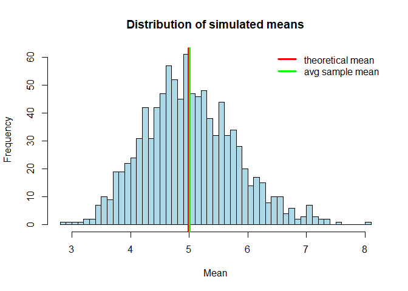

```r
mns <- apply(simdata,1,mean)
hist(mns,col="light blue",breaks=50, xlab = "Mean",main = "Distribution of simulated means")
abline(v=1/lambda,col="red",lwd=4)
abline(v=round(mean(mns),3),col="green",lwd=3)
legend('topright', c("theoretical mean","avg sample mean"), col=c("red", "green"), lty=c(1,1), lwd=c(3,3), bty = "n")
```

```r
comMeans<-paste('sample mean =', round(mean(mns),3), ', theoretical mean=', 1/lambda, sep = "", collapse = NULL)
comMeans
```

```
## [1] "sample mean =5.009, theoretical mean=5"
```

Above histogram shows: the sample mean is very closed to theoretical mean of distribution when having enough samples of the exponential distribution.

## 4.4 P1: Compare sample variance to the theoretical variance of the distribution

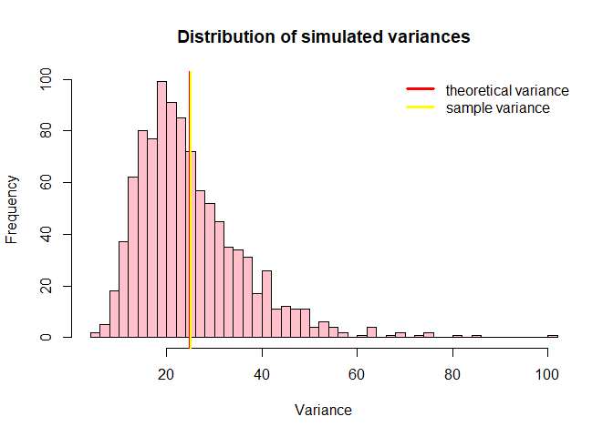

```r
vars <- apply(simdata,1,var)
hist(vars,col="pink",breaks=50, xlab = "Variance", main = "Distribution of simulated variances")
abline(v=1/lambda^2,col="red",lwd=3)
abline(v=round(mean(vars),3),col="yellow",lwd=2)
legend('topright', c("theoretical variance","sample variance"), col=c("red", "yellow"), lty=c(1,1), lwd=c(3,3), bty = "n")
```

```r
comVars<-paste('sample variance =', round(mean(vars),3), ', theoretical variance=', 1/lambda^2, sep = "", collapse = NULL)
comVars
```

```
## [1] "sample variance =25.096, theoretical variance=25"
```

Above histogram shows: the sample variance is very closed to theoretical variance of distribution when having enough samples of the exponential distribution.

## 4.5 P1: Compare the results to a normal distribution

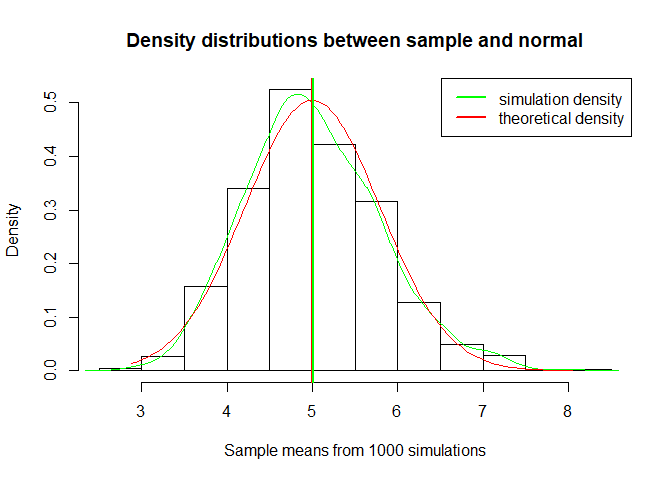

```r
## step 1 draw the histgram
hist(mns,  prob=T,
     main="Density distributions between sample and normal",
     xlab="Sample means from 1000 simulations")

# step 2 draw simulated sample mean density distribution
lines(density(mns), col="green", lty=1)


# step 3 draw therotical mean desnity distibution
x <- seq(min(mns), max(mns), length=100)
y <- dnorm(x, mean=1/lambda, sd=(1/lambda/sqrt(n)))
lines(x, y, col="red", lty=1)

# step 4 draw both sample mean and theoretical Mean
abline(v=1/lambda, col='red', lwd=2)
abline(v=round(mean(mns),3),col="green",lwd=2)

# step 5 insert legends
legend('topright', c("simulation density", "theoretical density"),
       lty=c(1,1), col=c("green", "red"), lwd=c(2,2))
```

Above histogram with overlay of sample/normal curves shows: the two distribution curves are very similar and normally distributed.

## 4.6 P1 Conclusion

- The sample mean is very close to the theoretical mean of the distribution.
- The sample variance is very close to the theoretical variance of the distribution.
- The sample distribution is approximately normal.

# 5 Part 2 (P2) Analyze the tooth growth

## 5.1 P2 Objectives

- Load the ToothGrowth data and perform some basic exploratory data analyses.
- Provide a basic summary of the data.
- Use confidence intervals and/or hypothesis tests to compare tooth growth by supp and dose.
- State your conclusions and the assumptions needed for your conclusions

## 5.2 P2: Load data and basic exploratory analyses

```r
data(ToothGrowth)
str(ToothGrowth)
```

```
## 'data.frame':    60 obs. of  3 variables:
##  $ len : num  4.2 11.5 7.3 5.8 6.4 10 11.2 11.2 5.2 7 ...
##  $ supp: Factor w/ 2 levels "OJ","VC": 2 2 2 2 2 2 2 2 2 2 ...
##  $ dose: num  0.5 0.5 0.5 0.5 0.5 0.5 0.5 0.5 0.5 0.5 ...
```

```r
summary(ToothGrowth)
```

```
##       len        supp         dose
##  Min.   : 4.20   OJ:30   Min.   :0.500
##  1st Qu.:13.07   VC:30   1st Qu.:0.500
##  Median :19.25           Median :1.000
##  Mean   :18.81           Mean   :1.167
##  3rd Qu.:25.27           3rd Qu.:2.000
##  Max.   :33.90           Max.   :2.000
```

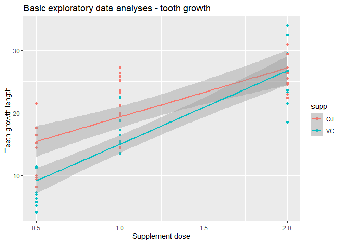

```r
qplot(dose, len, data = ToothGrowth, color = supp, geom = "point") +
        geom_smooth(method = "lm") +
        labs(title = "Basic exploratory data analyses - tooth growth ") +
        labs(x = "Supplement dose", y = "Teeth growth length ")
```

Findings from the above plot:

1. When supplement dose increases, the teeth length goes up for both OJ and VC.
2. Supplement OJ has a higher length increase than VC at the lower dose.

## 5.3 P2: Provide a basic summary of the data

```r
GroupSumStats <- sqldf('select supp, dose, max(len) as Max, min(len) as Min,
                        median(len) as Median, avg(len) as Mean,
                        round(stdev(len),2) as stdev, count(*) as n
                        from ToothGrowth group by supp, dose')
GroupSumStats
```

```
##   supp dose  Max  Min Median  Mean stdev  n
## 1   OJ  0.5 21.5  8.2  12.25 13.23  4.46 10
## 2   OJ  1.0 27.3 14.5  23.45 22.70  3.91 10
## 3   OJ  2.0 30.9 22.4  25.95 26.06  2.66 10
## 4   VC  0.5 11.5  4.2   7.15  7.98  2.75 10
## 5   VC  1.0 22.5 13.6  16.50 16.77  2.52 10
## 6   VC  2.0 33.9 18.5  25.95 26.14  4.80 10
```

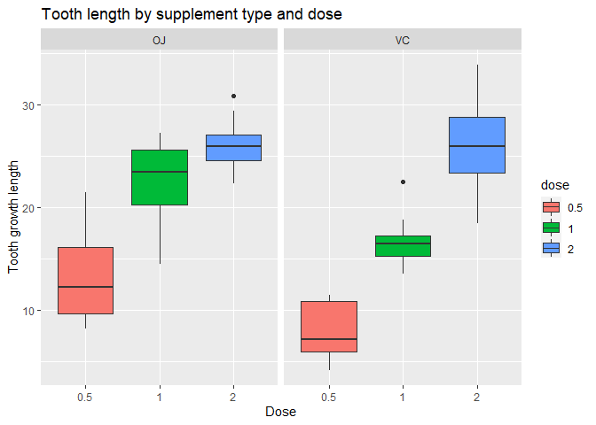

```r
#update dose as factor for analysis
ToothGrowth$dose<-as.factor(ToothGrowth$dose)

ggplot(aes(x=dose, y=len), data=ToothGrowth) +
        geom_boxplot(aes(fill=dose)) +
        xlab("Dose") +
        ylab("Tooth growth length") +
        facet_grid(~ supp) +
        ggtitle("Tooth length by supplement type and dose")
```

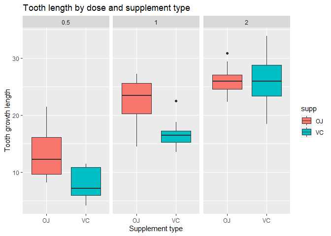

```r
ggplot(aes(x=supp, y=len), data=ToothGrowth) +
        geom_boxplot(aes(fill=supp)) +
        xlab("Supplement type") +
        ylab("Tooth growth length") +
        facet_grid(~ dose) +
        ggtitle("Tooth length by dose and supplement type")
```

## 5.4 P2: Compare tooth growth by supplement type and dose

### 5.4.1 P2: tooth growth by supplement type

```r
## OJ and VC data
OJ <- filter(ToothGrowth, supp == 'OJ')$len
VC <- filter(ToothGrowth, supp == 'VC')$len

## t- test by supplement type OJ and VC
t.test(OJ, VC, paired = FALSE, var.equal = FALSE)
```

```
##
##  Welch Two Sample t-test
##
## data:  OJ and VC
## t = 1.9153, df = 55.309, p-value = 0.06063
## alternative hypothesis: true difference in means is not equal to 0
## 95 percent confidence interval:
##  -0.1710156  7.5710156
## sample estimates:
## mean of x mean of y
##  20.66333  16.96333
```

Note: the p-value of this test is 0.06, which is greater than 0.05 and the confidence interval of the test contains zero. therefore, the supplement types seems to have no impact on tooth growth based on this test result.

### 5.4.2 P2: tooth growth by dose

```r
##  data by dose: 0.5,1.0 and  2.0
dose_0.5 <- filter(ToothGrowth, dose == 0.5)$len
dose_1.0 <- filter(ToothGrowth, dose == 1.0)$len
dose_2.0 <- filter(ToothGrowth, dose == 2.0)$len

## t- test by dose 0.5 and 1.0
t.test(dose_0.5, dose_1.0, paired = FALSE, var.equal = FALSE)
```

```
##
##  Welch Two Sample t-test
##
## data:  dose_0.5 and dose_1.0
## t = -6.4766, df = 37.986, p-value = 1.268e-07
## alternative hypothesis: true difference in means is not equal to 0
## 95 percent confidence interval:
##  -11.983781  -6.276219
## sample estimates:
## mean of x mean of y
##    10.605    19.735
```

```r
## t- test by dose 0.5 and 2.0
t.test(dose_0.5, dose_2.0, paired = FALSE, var.equal = FALSE)
```

```
##
##  Welch Two Sample t-test
##
## data:  dose_0.5 and dose_2.0
## t = -11.799, df = 36.883, p-value = 4.398e-14
## alternative hypothesis: true difference in means is not equal to 0
## 95 percent confidence interval:
##  -18.15617 -12.83383
## sample estimates:
## mean of x mean of y
##    10.605    26.100
```

```r
## t- test by dose 1.0 and 2.0
t.test(dose_1.0, dose_2.0, paired = FALSE, var.equal = FALSE)
```

```
##
##  Welch Two Sample t-test
##
## data:  dose_1.0 and dose_2.0
## t = -4.9005, df = 37.101, p-value = 1.906e-05
## alternative hypothesis: true difference in means is not equal to 0
## 95 percent confidence interval:
##  -8.996481 -3.733519
## sample estimates:
## mean of x mean of y
##    19.735    26.100
```

Note: from above three tests: the p-value of each test was essentially zero and the confidence interval of each test does not cross over zero (0). Therefore, the average tooth length increases with an inceasing dose.